# Section 3: Data processing, exploratory analysis and visualization

(Sukalp Muzumdar)

Import required libraries/packages

```r
package_list = c("dplyr", "ggplot2", "tibble",
                 "reshape2", "reactable", "ggpubr", "rstatix",
                 "parallel", "ggrepel", "tidyr", "stringr",
                 "dendsort", "reactablefmtr", "circlize",
                 "BiocManager")

bioc_packages = c("DESeq2", "fgsea", "ComplexHeatmap")

verify_packages <- lapply(package_list, FUN = function(x) {
  if (!require(x, character.only = TRUE)) {
    install.packages(x, dependencies = TRUE)
    library(x, character.only = TRUE)
  }
}
)

verify_packages_bioc <- lapply(bioc_packages, FUN = function(x) {
  if (!require(x, character.only = TRUE)) {
    BiocManager::install(x, dependencies = TRUE)
    library(x, character.only = TRUE)
  }
}
)
```

Start off by reading data into R from the provided CSV and view the general structure of the data.

```r
dat <- read.csv("gene_count_matrix.csv")
head(dat)
```

```
##     GeneSymbol    GeneID  A10 A12 A18 A20 A21  K11 K15  K17 K22 K23
## 1       WASH7P    653635 1083 805 973 892 592 1078 883 1036 912 584
## 2   MIR1302-10 100422834    0   0   2   1   0    0   1    0   1   0
## 3      FAM138A    645520   10   7   7   7   5    9   8    3   9   6
## 4        OR4F5     79501    5   1   0   0   0    0   0    3   0   0
## 5    LOC729737    729737  302 676 209 105  75  209 169  200 300 108
## 6 LOC100132287 100132287  208 406 265 170 151  212 213  242 216 112
```

Read the provided list of biomarkers (saved as a CSV file).

```r
biomarker_list <- read.csv("biomarkers.csv", header = FALSE, col.names = "genes")
biomarker_list <- biomarker_list$genes
```

Choosing to work with gene symbols here instead of gene IDs - construct a dataframe with genes as rows and samples as columns.

```r
mat <- dat %>%
  dplyr::select(-GeneID) %>%
  column_to_rownames("GeneSymbol")
```

Remove all genes with zero counts across all samples

```r
mat <- mat %>%
  mutate(s = rowSums(across(.cols = where(is.numeric)))) %>%
  filter(s > 0) %>%
  dplyr::select(-s)
```

Constructing a simple metadata dataframe with just two columns - sample name encoded as “smpl” and sample type (disease or control) encoded as “smpl_type” - samples prefixed with an “**A**” are the disease group, and those with a “**K**” are the control group.

```r
meta.data <- data.frame(smpl = colnames(mat)) %>%
  mutate(smpl_type =
           factor(ifelse(substr(smpl, 1, 1) == "A", "disease", "control"),
                  levels = c("control", "disease"))) %>%
  column_to_rownames("smpl")
```

Initialize a DESeq2 object to use its median-of-ratios normalization technique (calculates the geometric mean for each gene across samples, and divides each sample by the median of these ratios across all genes - thus helping correct for library size as well as for library composition).

```r
dds <- DESeqDataSetFromMatrix(countData = mat,
                              colData = meta.data,
                              design = ~ smpl_type)
```

Perform DESeq2 median-of-ratios normalization on dataset - first calculate size factors.

```r
dds <- estimateSizeFactors(dds)
```

Next, get the normalized count matrix back from DESeq2.

```r
norm_counts <- counts(dds, normalized = TRUE)
```

Some quick data wrangling to convert this normalized count matrix to a long format dataframe and then merging the raw and normalized counts into one dataframe.

```r
norm_counts <- merge(meta.data %>%
    rownames_to_column("smpl") %>%
    dplyr::select(smpl, smpl_type),
  data.frame(norm_counts) %>%
    rownames_to_column("gene") %>%
    melt(id.vars = "gene") %>%
    dplyr::rename(smpl = variable,
                  value.norm = value))

unnorm_counts <- merge(meta.data %>%
    rownames_to_column("smpl") %>%
    dplyr::select(smpl, smpl_type),
  data.frame(mat) %>%
    rownames_to_column("gene") %>%
    melt(id.vars = "gene") %>%
    dplyr::rename(smpl = variable,
                  value.raw = value))


final_mat <- merge(norm_counts, unnorm_counts)
```

```r
mapping_names_labels <-
  data.frame(names = c("smpl_type", "gene",
                       "raw.max", "raw.min",
                       "raw.mean", "raw.median",
                       "norm.max", "norm.min",
                       "norm.mean", "norm.median"),
             transformed = c("Sample Type", "Gene",
                             "Max. value (raw)",
                             "Min. value (raw)",
                             "Mean value (raw)",
                             "Median value (raw)",
                             "Max. value (norm.)",
                             "Min. value (norm.)",
                             "Mean value (norm.)",
                             "Median value (norm.)"))
tbl <- final_mat %>% filter(gene %in% biomarker_list) %>%
  group_by(gene, smpl_type) %>%
  mutate(raw.max = max(value.raw),
         raw.min = min(value.raw),
         raw.mean = mean(value.raw),
         raw.median = median(value.raw),
         norm.max = max(value.norm),
         norm.min = min(value.norm),
         norm.mean = mean(value.norm),
         norm.median = median(value.norm)) %>%
  dplyr::select(-smpl, -value.norm, -value.raw) %>%
  ungroup %>%
  unique %>%
  mutate(across(where(is.numeric), .fns = ~ round(., 2)))

colnames(tbl) <-
  mapping_names_labels$transformed[match(colnames(tbl),
                                         mapping_names_labels$names)]

tbl_out <- reactable(
  tbl %>% group_by(Gene) %>% arrange(Gene, `Sample Type`) %>%
    relocate(Gene),
  columns = list(
    Gene = colDef(
      style = JS("function(rinfo, col, s) {
        const first = s.sorted[0]
        if (!first || first.id === 'Gene') {
          const prev = s.pageRows[rinfo.viewIndex - 1]
          if (prev && rinfo.row['Gene'] === prev['Gene']) {
            return {visibility: 'hidden' }
          }
          else{
          return {fontStyle: 'italic', fontSize: 18}
          }
        }
      }")
    )
  ),

    height = 600, width = 1080
)

tbl_out %>% add_title("Summary statistics - biomarkers", align = "center")
```

# Summary statistics - biomarkers

| Gene | Sample Type | Max. value (raw) | Min. value (raw) | Mean value (raw) | Median value (raw) | Max. value (norm.) | Min. value (norm.) | Mean value (norm.) | Median value (norm.) |
| --- | --- | --- | --- | --- | --- | --- | --- | --- | --- |
| DLX3 | control | 7 | 2 | 5.4 | 6 | 6.97 | 2.48 | 5.54 | 6.19 |
| DLX3 | disease | 32 | 4 | 15.8 | 15 | 27.82 | 3.61 | 14.8 | 14.39 |
| KLK10 | control | 168 | 25 | 84.4 | 75 | 163.37 | 25.93 | 87.98 | 93.06 |
| KLK10 | disease | 42 | 14 | 25.4 | 23 | 39.37 | 12.59 | 24.1 | 23.48 |
| SCGB2A2 | control | 973 | 10 | 330.6 | 249 | 1009.35 | 12.41 | 337.75 | 242.14 |
| SCGB2A2 | disease | 1236 | 81 | 730.8 | 813 | 1074.4 | 73.16 | 694.41 | 906.5 |
| TAS2R43 | control | 69 | 0 | 33.6 | 30 | 85.61 | 0 | 37.39 | 29.87 |
| TAS2R43 | disease | 79 | 29 | 45.6 | 38 | 71.04 | 28.12 | 42.37 | 33.03 |
| TMEM252 | control | 2037 | 365 | 924.2 | 776 | 1980.88 | 378.63 | 964.26 | 800.97 |
| TMEM252 | disease | 1088 | 21 | 424.6 | 239 | 982.68 | 23.69 | 382.62 | 207.75 |

Next, plot individual boxplots for each gene - standardize data (convert to z-scores) to convert all genes to a comparable scale for ease of plotting

```r
biomarker_expr <- norm_counts %>%
  filter(gene %in% biomarker_list) %>%
  group_by(gene) %>%
  mutate(z =
           (value.norm - mean(value.norm))/sd(value.norm)) %>%
  ungroup
```

Perform two-sample t-tests to test for differences in scaled expression, and correct for multiple testing (using the Benjamini-Hochberg method)

```r
biomarker_stats <- biomarker_expr %>%
  group_by(gene) %>%
  t_test(z ~ smpl_type) %>%
  adjust_pvalue(p.col = "p", method = "BH") %>%
  add_significance(p.col = "p.adj") %>%
  add_y_position()
```

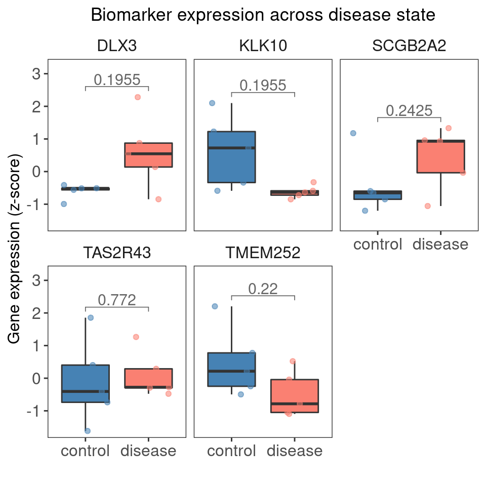

```r
biomarker_expr %>% ggplot() +
  geom_boxplot(aes(x = smpl_type,
      y = z,
      fill = smpl_type), outlier.shape = NA) +
  facet_wrap(~ gene) + geom_jitter(aes(x = smpl_type,
      y = z,
      col = smpl_type, alpha = .6)) +
  theme_bw() +
  theme(legend.position = "none",
        axis.title.x = element_text(size = 12),
        axis.title.y = element_text(size = 12),
        axis.text.x = element_text(size = 12),
        axis.text.y = element_text(size = 12),
        strip.text = element_text(size = 12),
        strip.background = element_blank(),
        panel.grid.major = element_blank(),
        panel.grid.minor = element_blank(),
        plot.title = element_text(hjust = 0.5)) +
  xlab("") +
  ylab("Gene expression (z-score)") +
  scale_fill_manual(values = c("steelblue", "salmon")) +
  scale_color_manual(values = c("steelblue", "salmon")) +
  stat_pvalue_manual(biomarker_stats, label = "p.adj",
                     color = "grey40", size = 4) +
  scale_y_continuous(expand = expansion(mult = c(0.05, 0.2))) +
  ggtitle("Biomarker expression across disease state")
```

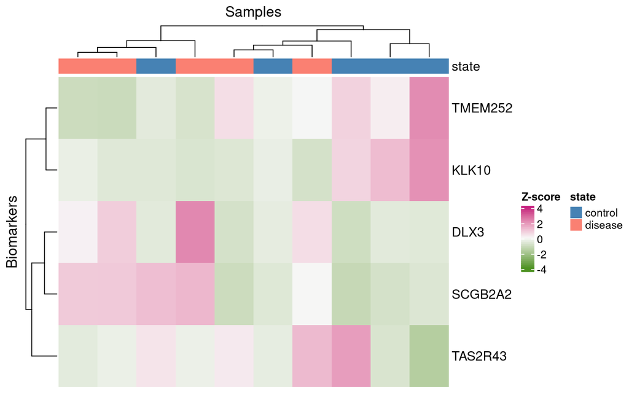

```r
mat <- norm_counts %>%
  pivot_wider(names_from = "gene", values_from = "value.norm")
mat <- mat %>%
  dplyr::select(-smpl) %>%
  dplyr::select(smpl_type, unlist(biomarker_list))

mat <- biomarker_expr %>%
  dplyr::select(-value.norm) %>%
  pivot_wider(names_from = "gene", values_from = "z") %>%
  dplyr::select(-smpl)

col_dend = dendsort(hclust(dist((mat[, -1]))))
col_fun = colorRamp2(c(-4, 0, 4),
                     c("#4D9221", "#F7F7F7", "#C51B7D"))

ha <- HeatmapAnnotation(state = mat$smpl_type,
                        name = "State",
                        col = list(state =
                                     c("disease" = "salmon",
                                       "control" = "steelblue")))

Heatmap(t(mat[,-1]), top_annotation = ha, name = "Z-score", cluster_columns = col_dend, col = col_fun, row_title = "Biomarkers",
        column_title = "Samples")
```

Can the expression of any of the biomarker genes classify disease samples from controls? This can be evaluated by looking at whether the normalized expression of any gene can accurately segregate the disease samples from the control samples. This can be evaluated by means of an AUROC using the following formula -

$${AUROC=\frac {U} {{N}_{disease}*{{N}_{control}}}}$$
(where U is the Mann-Whitney test statistic - Hanley and McNeil, 1982)

```r
res.pred.disease <- data.frame()

all_samples <- norm_counts %>% dplyr::select(smpl, smpl_type) %>% distinct

p_samples <- all_samples %>% filter(smpl_type == "disease") %>% nrow

n_samples <- all_samples %>% filter(smpl_type == "control") %>% nrow

x <- lapply(X = seq_along(biomarker_list), FUN = function(i)
  {
  gene.sig <- biomarker_list[[i]]
  #Calculate sum of ranks of "positives"
  sum_ranks <-
    norm_counts %>%
    filter(gene %in% gene.sig) %>%
    mutate(rank = rank(value.norm)) %>%
    filter(smpl_type == "disease") %>%
    dplyr::select(rank) %>% "[["(1) %>%
    sum
  #Calculate AUROC
  curr.auroc.test <- sum_ranks / (p_samples * n_samples) - (p_samples + 1) / (2 * n_samples)
  #Append gene-wise AUROCs to dataframe
  res.pred.disease <<-
    rbind(res.pred.disease, data.frame(n_genes = i, gene = gene.sig, roc = curr.auroc.test, mode = "test",
                                       clust = i))
})
```

The AUROC is evaluating the ability of each individual gene to rank disease samples above control samples, however since we have only 5 disease and 5 control samples, it is important to evaluate the null distribution of AUROCs by random permutation of the ordering of samples (since only a small number of AUROC values are possible). This task also lends itself rather well to multi-core processing as each permutation can be calculated individually.

```r
smpls.emp.dist.auroc <- data.frame(smpl = unique(norm_counts$smpl)) %>%
  mutate(smpl_type = factor(ifelse(substr(smpl, 1, 1) == "A", "disease", "control"), levels = c("control", "disease")))

p_samples <- smpls.emp.dist.auroc %>% filter(smpl_type == "disease") %>% nrow
n_samples <- smpls.emp.dist.auroc %>% filter(smpl_type == "control") %>% nrow

null.dist <-
  mclapply(seq(from = 1, to = 5000, by = 1), FUN = function(i){
    set.seed(i)
    curr.smpl <- smpls.emp.dist.auroc %>%
      mutate(rank = sample(seq_along(smpl), nrow(.)))
    sum_ranks <-
      curr.smpl %>%
      filter(smpl_type == "disease") %>%
      dplyr::select(rank) %>% "[["(1) %>%
      sum
    curr.auroc.test <- (sum_ranks /
      (p_samples * n_samples) - (p_samples + 1) / (2 * n_samples))
}, mc.cores = 25)

emp.null <- data.frame(auroc = unlist(null.dist))

upper_bound <- emp.null %>%
  top_frac(n = 0.025, wt = auroc) %>%
  min %>%
  round(2)

lower_bound <- emp.null %>%
  top_frac(n = -0.025, wt = auroc) %>%
  max %>%
  round(2)
```

Plot the gene-level AUROCs, with the upper and lower thresholds as defined from the empirical null model. An AUROC value of more than 0.5 indicates that the disease samples were preferentially ranked above the control samples, and conversely a value below 0.5 indicates the disease samples were preferentially ranked below the control samples. An AUROC of exactly 0.5 represents random classification. DLX3 and KLK10 may have some value as a biomarker, however more samples/replicates are definitely needed to gain more confidence.

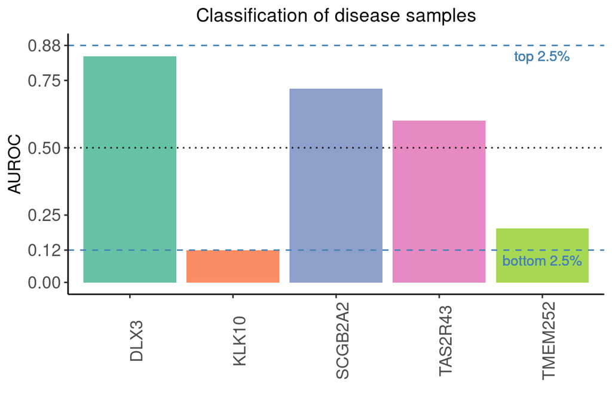

```r
res.pred.disease %>%
  ggplot() + aes(x = gene, y = roc, fill = gene) +
  geom_bar(stat = 'identity') +
  scale_y_continuous(breaks =
                       sort(c(seq(0, 1, length.out = 5), upper_bound, lower_bound))) +
  theme(legend.position = "none",
        axis.text.x = element_text(angle = 90)) +
  theme_classic() +
  geom_hline(yintercept = 0.5, linetype = "dotted") +
  geom_hline(yintercept = upper_bound, linetype = "dashed", color = "steelblue") +
  geom_hline(yintercept = lower_bound, linetype = "dashed", color = "steelblue") +
  geom_text(aes(x = 5, y = upper_bound, label = "\ntop 2.5%"),
            size = 3.5, color = "steelblue") +
  geom_text(aes(x = 5, y = lower_bound, label = "\nbottom 2.5%"),
            size = 3.5, color = "steelblue") +
  theme(legend.position = "none",
        axis.title.x = element_text(size = 12),
        axis.title.y = element_text(size = 12),
        axis.text.x = element_text(size = 12, angle = 90),
        axis.text.y = element_text(size = 12),
        strip.text = element_text(size = 12),
        strip.background = element_blank(),
        plot.title = element_text(hjust = 0.5)) +
  ylab("AUROC") +
  xlab("") +
  ggtitle("Classification of disease samples") +
  scale_fill_brewer(palette = "Set2")
```

Quick additional data exploration - function to calculate PCA and plot graph (adapted slightly from DESeq2)

```r
plotPCA_ <- function (object, intgroup = "condition", ntop = 500, returnData = FALSE, title)
{
    rv <- rowVars(assay(object))
    select <- order(rv, decreasing = TRUE)[seq_len(min(ntop,
        length(rv)))]
    pca <- prcomp(t(assay(object)[select, ]))
    percentVar <- pca$sdev^2/sum(pca$sdev^2)
    if (!all(intgroup %in% names(colData(object)))) {
        stop("the argument 'intgroup' should specify columns of colData(dds)")
    }
    intgroup.df <- as.data.frame(colData(object)[, intgroup,
        drop = FALSE])
    group <- if (length(intgroup) > 1) {
        factor(apply(intgroup.df, 1, paste, collapse = ":"))
    }
    else {
        colData(object)[[intgroup]]
    }
    d <- data.frame(PC1 = pca$x[, 1], PC2 = pca$x[, 2], group = group,
        intgroup.df, name = colnames(object))
    if (returnData) {
        attr(d, "percentVar") <- percentVar[1:2]
        return(d)
    }
    ggplot(data = d, aes_string(x = "PC1", y = "PC2", color = "group")) +
        geom_point(size = 3) + xlab(paste0("PC1: ", round(percentVar[1] *
        100), "% variance")) + ylab(paste0("PC2: ", round(percentVar[2] *
        100), "% variance")) + ggtitle(title) +
      theme(plot.title = element_text(hjust = 0.5,
                                      size = 15,
                                      vjust = 0.1,
                                      face = "bold"),
        axis.title = element_text(size = 15),
        axis.text = element_text(size = 15),
        legend.text = element_text(size = 12),
        legend.title = element_text(size = 12))
}
```

Apply variance-stabilizing transformation to expression matrix

```r
vsd <- vst(dds)
```

Principal component analysis on expression matrix does not reveal separation by disease state

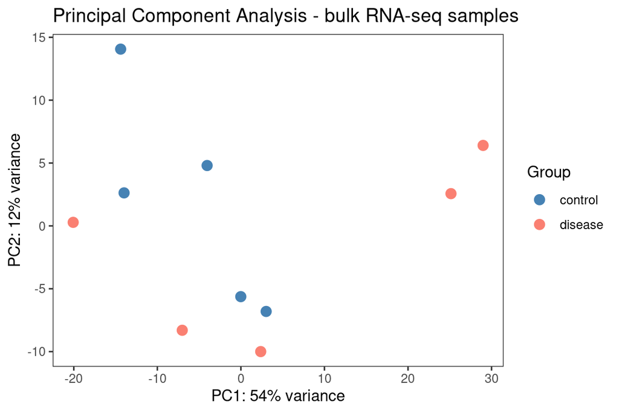

```r
plotPCA_(vsd, intgroup = "smpl_type",
         title = "Principal Component Analysis - bulk RNA-seq samples") + theme_bw() +
  theme(panel.grid.major = element_blank(),
        panel.grid.minor = element_blank()) +
  scale_color_manual(name = "Group",
                     breaks = c("control", "disease"),
                     values = c("steelblue", "salmon"),
                     labels = c("control", "disease"))
```

Differential expression testing across disease state (disease vs. control)

```r
dds <- DESeq(dds)

de_results <- results(dds,
                      contrast = c("smpl_type", "disease", "control"))

de_results <- lfcShrink(dds,
                        contrast = c("smpl_type", "disease", "control"),
                        type = "ashr",
                        res = de_results)

de_tbl <- data.frame(de_results) %>%
  rownames_to_column("gene")
```

Volcano plot to display top up- and down-regulated genes in disease state vs controls - uses a threshold of abs(log2FC) > 1.0 and adj. P-value < 0.05 to select genes which are DE. Also, genes which are assigned a NA adj. P value by DESeq2 are excluded (genes which did not pass independent filtering/have outliers as measured by Cook’s distance)

```r
`%notin%` <- Negate(`%in%`)
l2fc_thresh = 1.0
padj_thresh = 0.05

filt_de_tbl <-
  de_tbl %>%
  filter(!is.na(padj))
```

Plot volcano plot as specified above

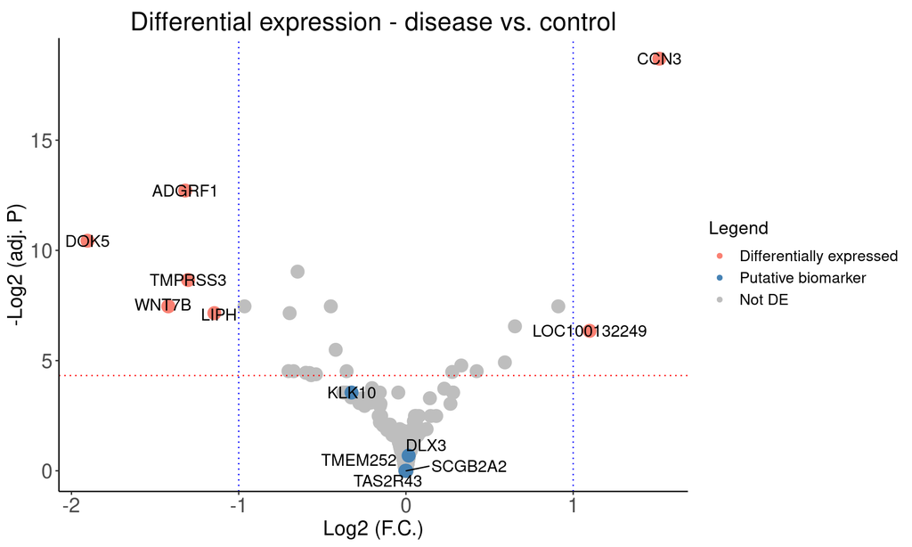

```r
rbind(subset(filt_de_tbl,
             gene %notin% biomarker_list),
      subset(filt_de_tbl,
             gene %in% biomarker_list)) %>%
  ggplot() +
  aes(x = log2FoldChange, y = -log2(padj)) +
  geom_jitter(aes(color =
                    case_when((abs(log2FoldChange) > l2fc_thresh & padj < padj_thresh) ~ "1",
                              gene %in% biomarker_list ~ "2",
                              TRUE ~ "3"),
                  size = 20)) +
  geom_vline(xintercept = -1 * l2fc_thresh, color = "blue", linetype = "dotted") +
  geom_vline(xintercept = 1 * l2fc_thresh, color = "blue", linetype = "dotted") +
  geom_hline(yintercept = -log2(padj_thresh), color = "red", linetype = "dotted") +
  geom_text_repel(max.overlaps = 20,
                  aes(x = log2FoldChange, y = -log2(padj), label = gene, size = 20, point.size = NA),
                  data = filt_de_tbl %>% filter(abs(log2FoldChange) > l2fc_thresh & -log2(padj) > -log2(padj_thresh))) +
  geom_text_repel(max.overlaps = 20,
                  aes(x = log2FoldChange, y = -log2(padj), label = gene, size = 20, point.size = NA),
                  data = filt_de_tbl %>% filter(gene %in% biomarker_list)) +
  scale_color_manual(name = "Legend",
                     values = c("salmon", "steelblue", "grey"),
                     breaks = c("1", "2", "3"),
                     labels = c("Differentially expressed",
                                "Putative biomarker",
                                "Not DE")) +
  scale_size(guide = "none") +
  ggtitle("Differential expression - disease vs. control") +
  xlab("Log2 (F.C.)") +
  ylab("-Log2 (adj. P)") +
  theme_classic() +
  theme(plot.title = element_text(hjust = 0.5,
                                  size = 20,
                                  vjust = 0.1),
        axis.title = element_text(size = 16),
        axis.text = element_text(size = 16),
        strip.text = element_text(size = 16),
        legend.title = element_text(size = 14),
        legend.text = element_text(size = 12))
```

Enrichment analysis is performed in a fashion similar to GSEA (which uses the K-S test) Load GO terms from MSigDb for enrichment analyses

```r
GO_complete <- fgsea::gmtPathways("genesets/c5.go.v7.2.symbols.gmt")
GO_subset <- list()
x <- lapply(names(GO_complete), function(i){
  GO_subset[[i]] <<-
    GO_complete[[i]][GO_complete[[i]] %in% filt_de_tbl$gene]
})
```

Perform enrichment analyses on full DE table using the Mann-Whitney test - First rank genes based on where they occur in the DE table - next perform a Mann-Whitney test on the ranks of genes which occur in a specific gene set versus genes which do not occur in that particular gene set. This allows for a sensitive detection of subtle shifts in the ranking of genes associated with any gene set, pointing towards changes in functional terms. The functions for performing these analyses are defined below.

```r
#Prep gene list for M-W-style enrichment analysis
prepRankedGeneList <- function(filt_de_tbl){
  l2fc <- filt_de_tbl %>% dplyr::select(log2FoldChange) %>% "[["(1)
  names(l2fc) <- filt_de_tbl %>% dplyr::select(gene) %>% "[["(1)
  rank_l2fc <- rank(l2fc, ties.method = "average")
  return(rank_l2fc)
}


#Mann-Whitney-style enrichment on whole DE table
genesetEnrichment <-
  function(ranked_list, gene_set_list,
           max_size_gene_set = 200,
           min_size_gene_set = 10,
           hypothesis = "two.sided"){


    gene_list <- names(ranked_list)

    subset_gene_set_list <- list()

    x <- lapply(names(gene_set_list), function(i){
      subset_gene_set_list[[i]] <<- gene_set_list[[i]][gene_set_list[[i]] %in% gene_list]
      })

    keep <- lapply(seq_along(subset_gene_set_list),
           function(i){
             ifelse(
               ((length(subset_gene_set_list[[i]]) > min_size_gene_set) &
                 (length(subset_gene_set_list[[i]]) < max_size_gene_set)), TRUE, FALSE)
           })

    filt_gene_set <- subset_gene_set_list[unlist(keep)]

    raw <- data.frame()

    enrich_res <- mclapply(seq_along(filt_gene_set), function(i){

      data.frame(geneset = names(filt_gene_set)[i],
                 n_shared =
                   length(ranked_list[unlist(filt_gene_set[i])]),

                 n_not_shared =
                   length(ranked_list[-c(which(names(ranked_list) %in% unlist(filt_gene_set[i])))]),

                 avg_rank_shared =
                   mean(ranked_list[unlist(filt_gene_set[i])]),

                 avg_rank_not_shared =
                   mean(ranked_list[-c(which(names(ranked_list) %in% unlist(filt_gene_set[i])))]),

                 pval =
                   wilcox.test(ranked_list[unlist(filt_gene_set[i])],
                                    ranked_list[-c(which(names(ranked_list) %in% unlist(filt_gene_set[i])))],
                                    alternative = hypothesis)$p.value)
    }, mc.cores = 25)

  raw <- bind_rows(enrich_res) %>%
    mutate(padj = p.adjust(pval, "BH"))
  return(raw)
}
```

Perform the enrichment analysis

```r
enrich <-
  rbind(genesetEnrichment(ranked_list = prepRankedGeneList(filt_de_tbl),
                                gene_set_list = GO_subset, max_size_gene_set = 100,
                                hypothesis = "greater") %>% mutate(dir = "up"),
  genesetEnrichment(ranked_list = prepRankedGeneList(filt_de_tbl),
                                gene_set_list = GO_subset, max_size_gene_set = 100,
                                hypothesis = "less") %>% mutate(dir = "down"))
```

Make GO term names look a bit more friendly

```r
go_plot <- enrich
go_plot$geneset <- str_split(go_plot$geneset, "GO_", simplify = TRUE)[, 2]
go_plot$geneset <- str_replace_all(go_plot$geneset, "_", " ")
```

Plot enriched GO terms in up-regulated genes (genes in geneset preferentially occur towards the top of the DE table)

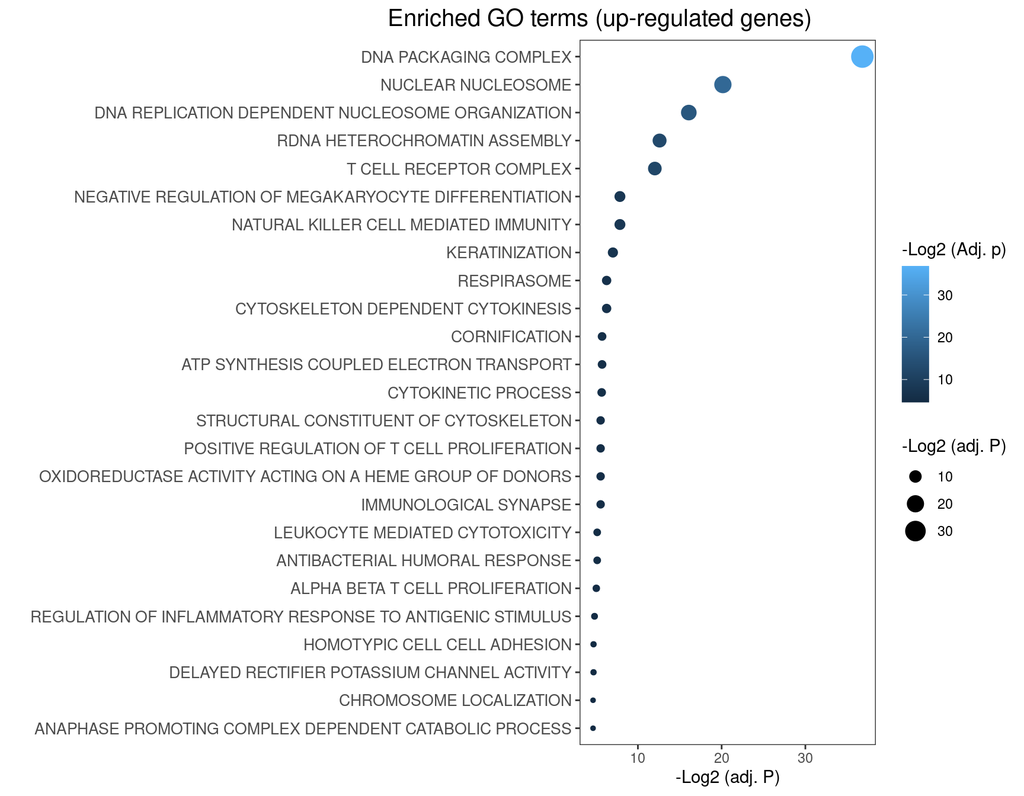

```r
go_plot %>%
  arrange(padj) %>%
  filter(dir == "up" & padj <= 0.1) %>%
  head(n = 25) %>%
  ggplot() +
  aes(x = -log2(padj),
      y = reorder(geneset, -log2(padj)),
      size = -log2(padj),
      col = -log2(padj)) +
  geom_point(position = position_dodge(width = 0.5)) +

    xlab("-Log2 (adj. P)") +
    ylab("") + theme_bw() +
    theme(panel.grid = element_blank(),
          axis.text.y = element_text(size = 10),
          plot.title = element_text(hjust = 1.5, size = 15)) +
    scale_size_continuous(name = "-Log2 (adj. P)") +
  scale_color_continuous(name = "-Log2 (Adj. p)") +
    ggtitle("Enriched GO terms (up-regulated genes)")
```

Plot enriched GO terms in down-regulated genes (genes in geneset preferentially occur towards the bottom of the DE table)

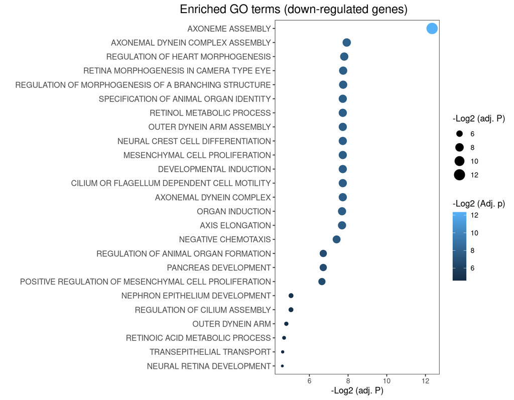

```r
go_plot %>%
  arrange(padj) %>%
  filter(dir == "down" & padj <= 0.1) %>%
  head(n = 25) %>%
  ggplot() +
  aes(x = -log2(padj),
      y = reorder(geneset, -log2(padj)),
      size = -log2(padj),
      col = -log2(padj)) +
  geom_point(position = position_dodge(width = 0.5)) +

    xlab("-Log2 (adj. P)") +
    ylab("") + theme_bw() +
    theme(panel.grid = element_blank(),
          axis.text.y = element_text(size = 10),
          plot.title = element_text(hjust = 1.5, size = 15)) +
    scale_size_continuous(name = "-Log2 (adj. P)") +
  scale_color_continuous(name = "-Log2 (Adj. p)") +
  ggtitle("Enriched GO terms (down-regulated genes)")
```